# Premier League Data Analysis

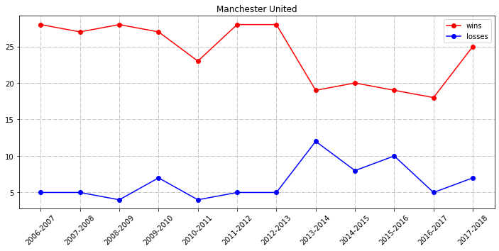

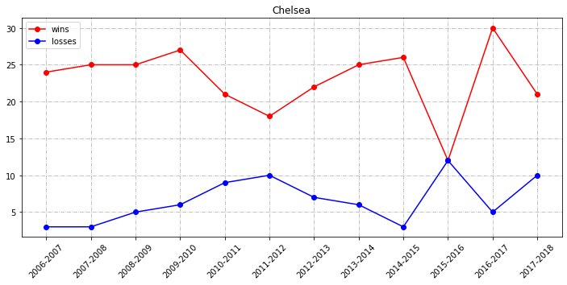

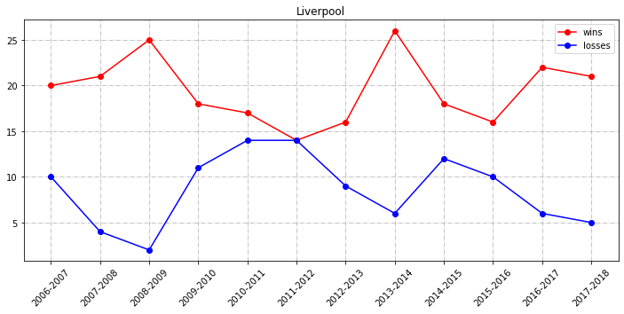

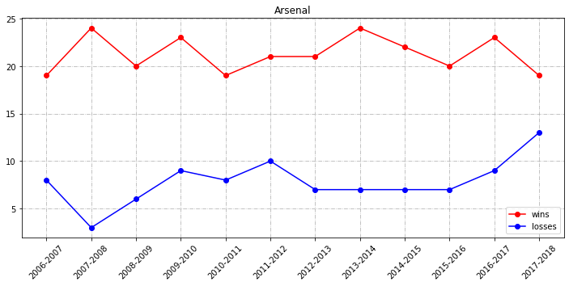

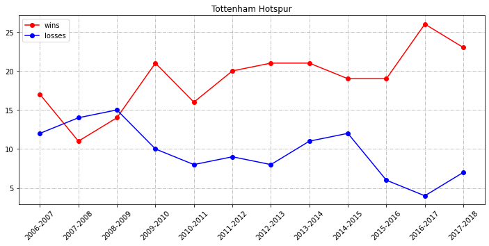

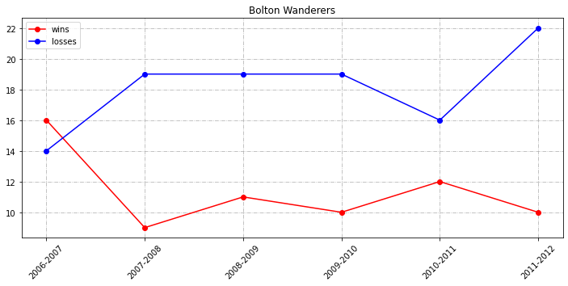

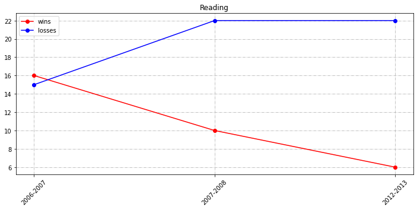

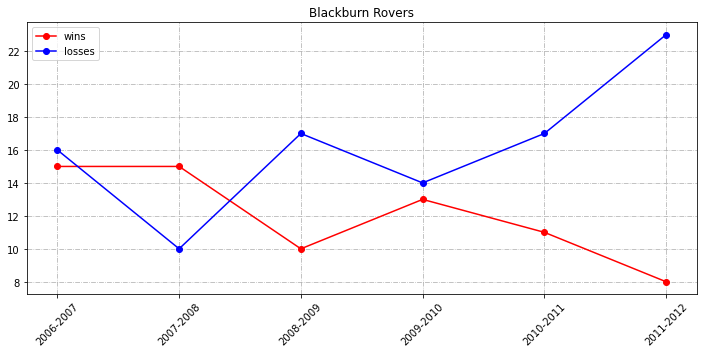

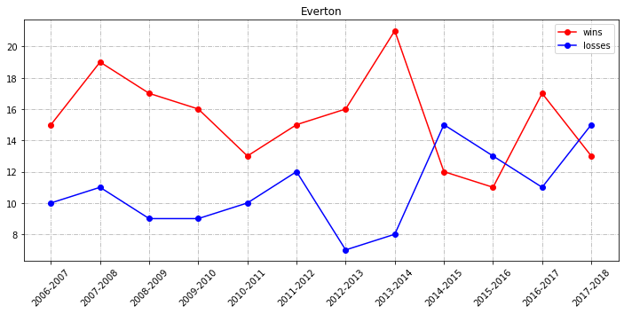

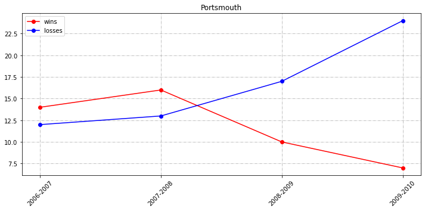

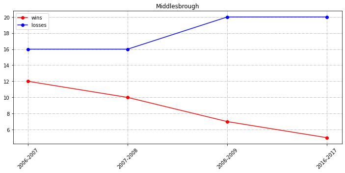

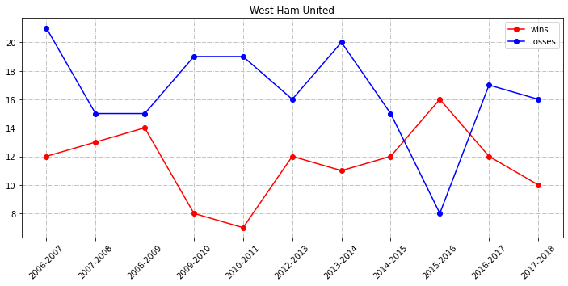

[27 more figures not shown]

```python
team_list = df2.team.unique()
for team in team_list:
    x = df2[df2.team == team]
    plt.figure(figsize = (12,5))
    plt.plot(x.season, x.wins, color = 'red', marker = "o")
    plt.plot(x.season, x.losses, color = 'blue', marker = "o")
    plt.legend(['wins','losses'])
    plt.xticks(rotation = 45)
    plt.title(team)
    plt.grid(linestyle ='-.',linewidth = 0.75)
    plt.show()
```

```python
pre_stats_united = df2[(df2.team == 'Manchester United')]
```

Since Manchester United has been through very tough times after the era of Sir Alex Ferguson, we decided to have a visualization to see how new coaches performed when they were in charge of the team. David Moyes was the chosen one right after Sir Alex's time. However, not only his winning rate was low, but also his loss rate was significantly higher than other seasons' data. On the other hand, Luis Van Gaal did a little better for two seasons, before Jose Mourinho was appointed in mid-2016. Overall, the "Special One" Mourinho was the best as he reached the highest winning rate during the 2017 - 2018 season with the lowest loss rate compared to the two others as well.

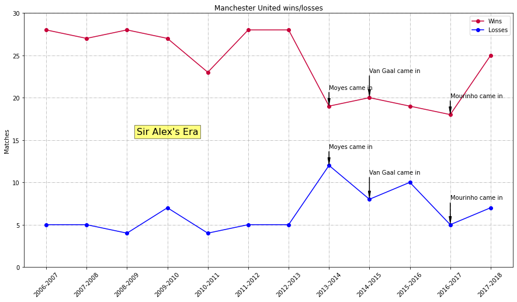

```python
plt.figure(figsize = (15,8))
plt.plot(pre_stats_united.season, pre_stats_united.wins, label = "Wins", marker = 'o',color = '#C70039')
plt.plot(pre_stats_united.season, pre_stats_united.losses, label = "Losses", marker = 'o',color = 'blue')
x = df['season']
plt.xticks(rotation = 45)
plt.ylabel('Matches')
plt.title('Manchester United wins/losses')
plt.ylim(0,30)
plt.grid(linestyle ='-.',linewidth = 0.75)
plt.legend()
plt.annotate('Moyes came in', xy=('2013-2014',19), xytext=('2013-2014', 21),arrowprops=dict(color='black', shrink=0.05, width=0.5, headwidth=4), fontsize =10)
plt.annotate('Moyes came in', xy=('2013-2014',12), xytext=('2013-2014', 14),arrowprops=dict(color='black', shrink=0.05, width=0.5, headwidth=4), fontsize =10)
plt.annotate('Van Gaal came in', xy=('2014-2015',20), xytext=('2014-2015', 23),arrowprops=dict(color='black', shrink=0.05, width=0.5, headwidth=4), fontsize =10)
plt.annotate('Van Gaal came in', xy=('2014-2015',8), xytext=('2014-2015', 11),arrowprops=dict(color='black', shrink=0.05, width=0.5, headwidth=4), fontsize =10)
plt.annotate('Mourinho came in', xy=('2016-2017',18), xytext=('2016-2017', 20),arrowprops=dict(color='black', shrink=0.05, width=0.5, headwidth=4), fontsize =10)
plt.annotate('Mourinho came in', xy=('2016-2017',5), xytext=('2016-2017', 8),arrowprops=dict(color='black', shrink=0.05, width=0.5, headwidth=4), fontsize =10)
plt.text('2009-2010',16,"Sir Alex's Era", horizontalalignment='center', verticalalignment='center', fontsize =16, bbox=dict(facecolor='yellow', alpha=0.5))
```